# Modeling To Predict School District’s Ranking

Brenndan Olson

### Intro

In the first phase I looked into state funding for public school districts. I am going to use that data to build a predictive model for a district’s ranking within their state based on state revenue and other factors. I am hoping to find a correlation between the amount of money a school receives and their rank to better understand how spending money in school districts can make for a better learning environment. After the model is built, we can compare it with real values and see if it holds up. First I am going to install the necessary libraries(if necessary) then load them, and run the code from the previous phase to have the appropriate clean and tidy data.

```r
if( !("rvest" %in% installed.packages()) )
install.packages("rvest")
if( !("tidyverse" %in% installed.packages()) )
install.packages("tidyverse")
if( !("dplyr" %in% installed.packages()) )
install.packages("dplyr")
if( !("caret" %in% installed.packages()) )
install.packages("caret")
if( !("knitr" %in% installed.packages()) )
install.packages("knitr")
suppressWarnings(library(rvest))
suppressWarnings(library(tidyverse))
suppressWarnings(library(dplyr))
suppressWarnings(library(caret))
suppressWarnings(library(knitr))
```

```r
purl("deliverable1.Rmd", output = "part1.r")
```

```
##
##
## processing file: deliverable1.Rmd
```

[output not shown]

```
## output file: part1.r
```

```
## [1] "part1.r"
```

```r
source("part1.r")
```

Currently we have two data tables, one called school_districts that contains all of the general information on each district, and state_revenue, which holds each district’s state funding for various programs/services.

```r
head(as_tibble(school_districts))
```

```
## # A tibble: 6 x 9
##   state id_number school_district ANSI_code consolidated_st…
##   <chr>     <dbl> <chr>               <int>            <int>
## 1 Alab…   1.50e12 AUTAUGA COUNTY…      1001               NA
## 2 Alab…   1.50e12 BALDWIN COUNTY…      1003              108
## 3 Alab…   1.50e12 BARBOUR COUNTY…      1005               NA
## 4 Alab…   1.50e12 EUFAULA CITY S…      1005               NA
## 5 Alab…   1.50e12 BIBB COUNTY SC…      1007                9
## 6 Alab…   1.50e12 BLOUNT COUNTY …      1009                9
## # … with 4 more variables: core_based_statistical_area <int>,
## #   school_level <chr>, nces_id <int>, fall_attendance <int>
```

```r
head(as_tibble(state_revenue))
```

```
## # A tibble: 6 x 19
##   state school_district fall_attendance general_formula… staff_improveme…
##   <chr> <chr>                     <int>            <int>            <int>
## 1 Alab… AUTAUGA COUNTY…            9307            47256               65
## 2 Alab… BALDWIN COUNTY…           31268           133128              101
## 3 Alab… BARBOUR COUNTY…             847             4124               40
## 4 Alab… EUFAULA CITY S…            3949            15639               61
## 5 Alab… BIBB COUNTY SC…            3291            18375               57
## 6 Alab… BLOUNT COUNTY …            7793            42013               49
## # … with 14 more variables: special_education_programs <int>,
## #   compensatory_and_basic_skills <int>, billingual_education <int>,
## #   gifted_and_talented <int>, vocational_education <int>,
## #   school_lunch <int>, capital_outlay_and_debt_service <int>,
## #   transportation <int>, other_state_revenue <int>,
## #   nces_local_revenue <int>, nonspecified_state_revenue <int>,
## #   state_payments_benefits <int>, state_payments_nonbenefits <int>,
## #   total_state_revenue <int>
```

### Web Scraping

To get an additional data source I am going to web scrape from a website called schooldigger.com that contains rankings for each school district within their respective state. I am going to use the link for the read_html() function that will make it possible for us to “scrape” out the information we want.

```r
html_link <- "https://www.schooldigger.com/go/AL/districtrank.aspx?y=2018"
html <- read_html(html_link)
```

Inside the html link we gave it, we are going to look for nodes under the name “table”

```r
tabl <- html %>% html_nodes("table")
t <- html_table(tabl)
head(t[[1]])
```

```
##   Rank (of 129)                             District Grades
## 1               Acceleration Day and Evening Academy     NA
## 2                        Alabama School of Fine Arts     NA
## 3          18th                       Alabaster City     NA
## 4          68th                     Albertville City     NA
## 5          76th                       Alexander City     NA
## 6          66th                       Andalusia City     NA
##   # Elementary Schools # Middle Schools # High Schools # Alt. Schools
## 1                    0                0              1              0
## 2                    0                0              0              0
## 3                    3                2              1              0
## 4                    3                2              1              0
## 5                    2                2              1              0
## 6                    1                1              1              0
##             City     County Rank score (2018) Rank (2017)
## 1         Mobile     Mobile                NA          NA
## 2     Birmingham  Jefferson                NA          NA
## 3      Alabaster     Shelby             0.801          17
## 4    Albertville   Marshall             0.505          93
## 5 Alexander City Tallapoosa             0.480          84
## 6      Andalusia  Covington             0.511          31
##   Rank change from 2017 SchoolDigger Rating (2018)
## 1                 (n/a)                         NA
## 2                 (n/a)                         NA
## 3                     1                         NA
## 4                    25                         NA
## 5                     8                         NA
## 6                    35                         NA
```

We are going to use that scraped data to make another tibble called district_rankings_2017. The only two columns we need are the school district and rank, and we are also going to omit any school districts that don’t have a ranking. While there is potentially a lot to be explored with unranked districts, it is hard to compare them against each other, and they do not provide much support for the model we are going to build later.

```r
district_rankings_2017 <- dplyr::tibble(
  school_district = t[[1]]$District,
  rank = t[[1]]$`Rank (2017)`)

district_rankings_2017 <- district_rankings_2017 %>%
  na.omit(cols = "rank")
head(district_rankings_2017)
```

```
## # A tibble: 6 x 2
##   school_district   rank
##   <chr>            <int>
## 1 Alabaster City      17
## 2 Albertville City    93
## 3 Alexander City      84
## 4 Andalusia City      31
## 5 Anniston City      119
## 6 Arab City            6
```

To make sure that both datasets have the same name and format for school districts, I am going to modify the school_district column of district_rankings_2017 to append “School District” to every district name, and make every character uppercase to match how they are written in the school_districts table

```r
district_rankings_2017$school_district <-
  lapply(district_rankings_2017$school_district, function(x) paste(x,'School District')) %>%
  sapply(toupper)
head(district_rankings_2017$school_district)
```

```
## [1] "ALABASTER CITY SCHOOL DISTRICT"   "ALBERTVILLE CITY SCHOOL DISTRICT"
## [3] "ALEXANDER CITY SCHOOL DISTRICT"   "ANDALUSIA CITY SCHOOL DISTRICT"
## [5] "ANNISTON CITY SCHOOL DISTRICT"    "ARAB CITY SCHOOL DISTRICT"
```

Since we are only focusing on one state, I am going to create a new table filtered with the state we are using. Using that, we can left join with district_rankings_2017 and add some of the variables we are going to use to build a predictive model.

```r
school_districts_alabama <- school_districts %>%
  dplyr::filter(state == "Alabama")
state_revenue_alabama <- state_revenue %>%
  dplyr::filter(state == "Alabama")
head(state_revenue_alabama)
```

```
## # A tibble: 6 x 19
##   state school_district fall_attendance general_formula… staff_improveme…
##   <chr> <chr>                     <int>            <int>            <int>
## 1 Alab… AUTAUGA COUNTY…            9307            47256               65
## 2 Alab… BALDWIN COUNTY…           31268           133128              101
## 3 Alab… BARBOUR COUNTY…             847             4124               40
## 4 Alab… EUFAULA CITY S…            3949            15639               61
## 5 Alab… BIBB COUNTY SC…            3291            18375               57
## 6 Alab… BLOUNT COUNTY …            7793            42013               49
## # … with 14 more variables: special_education_programs <int>,
## #   compensatory_and_basic_skills <int>, billingual_education <int>,
## #   gifted_and_talented <int>, vocational_education <int>,
## #   school_lunch <int>, capital_outlay_and_debt_service <int>,
## #   transportation <int>, other_state_revenue <int>,
## #   nces_local_revenue <int>, nonspecified_state_revenue <int>,
## #   state_payments_benefits <int>, state_payments_nonbenefits <int>,
## #   total_state_revenue <int>
```

```r
districts_with_rankings_2017 <- left_join(school_districts_alabama,district_rankings_2017, by = "school_district")
districts_with_rankings_2017 <- districts_with_rankings_2017 %>%
  dplyr::mutate(state_rev = state_revenue_alabama$total_state_revenue) %>%
  dplyr::mutate(general_formula_assistance = state_revenue_alabama$general_formula_assistance) %>%
  dplyr::mutate(staff_improvement_programs = state_revenue_alabama$staff_improvement_programs) %>%
  dplyr::mutate(other_state_revenue = state_revenue_alabama$other_state_revenue) %>%
  na.omit(cols = "rank")
head(districts_with_rankings_2017)
```

```
## # A tibble: 6 x 14
##   state id_number school_district ANSI_code consolidated_st…
##   <chr>     <dbl> <chr>               <int>            <int>
## 1 Alab…   1.50e12 BALDWIN COUNTY…      1003              108
## 2 Alab…   1.50e12 BIBB COUNTY SC…      1007                9
## 3 Alab…   1.50e12 BLOUNT COUNTY …      1009                9
## 4 Alab…   1.50e12 ONEONTA CITY S…      1009                9
## 5 Alab…   1.50e12 CHAMBERS COUNT…      1017               31
## 6 Alab…   1.50e12 LANETT CITY SC…      1017               31
## # … with 9 more variables: core_based_statistical_area <int>,
## #   school_level <chr>, nces_id <int>, fall_attendance <int>, rank <int>,
## #   state_rev <int>, general_formula_assistance <int>,
## #   staff_improvement_programs <int>, other_state_revenue <int>
```

### Modeling and Visualization

To create a predictive model, we want to have our data split into two tables, the training table and the test table. The training table contains 75% of the data, and is used for making the model. The testing table has the remaining 25% of data and is used to assess the model’s precision. To randomly separate the data there is a neat function called createDataPartition().

```r
index <- createDataPartition(districts_with_rankings_2017$rank, p = 0.75, list = FALSE)
train <- districts_with_rankings_2017[index,]
test <- districts_with_rankings_2017[-index,]
```

```r
model <- lm(train, formula = rank~state_rev + fall_attendance + general_formula_assistance + staff_improvement_programs + other_state_revenue)
summary(model)
```

```
##
## Call:
## lm(formula = rank ~ state_rev + fall_attendance + general_formula_assistance +
##     staff_improvement_programs + other_state_revenue, data = train)
##
## Residuals:
##     Min      1Q  Median      3Q     Max
## -60.377 -29.000  -3.074  30.028  74.570
##
## Coefficients:
##                             Estimate Std. Error t value Pr(>|t|)
## (Intercept)                47.199723  12.409212   3.804 0.000446 ***
## state_rev                   0.014796   0.006277   2.357 0.023046 *
## fall_attendance             0.003938   0.009859   0.399 0.691544
## general_formula_assistance -0.018328   0.008715  -2.103 0.041352 *
## staff_improvement_programs  0.344574   0.216367   1.593 0.118589
## other_state_revenue        -0.015077   0.009212  -1.637 0.108983
## ---
## Signif. codes:  0 '***' 0.001 '**' 0.01 '*' 0.05 '.' 0.1 ' ' 1
##
## Residual standard error: 36.01 on 43 degrees of freedom
## Multiple R-squared:  0.1429, Adjusted R-squared:  0.04325
## F-statistic: 1.434 on 5 and 43 DF,  p-value: 0.2315
```

```r
model <- lm(train, formula = rank~state_rev + fall_attendance + general_formula_assistance + staff_improvement_programs)
summary(model)
```

```
##
## Call:
## lm(formula = rank ~ state_rev + fall_attendance + general_formula_assistance +
##     staff_improvement_programs, data = train)
##
## Residuals:
##     Min      1Q  Median      3Q     Max
## -78.698 -27.729  -2.308  29.004  74.538
##
## Coefficients:
##                              Estimate Std. Error t value Pr(>|t|)
## (Intercept)                45.9352300 12.6192202   3.640 0.000713 ***
## state_rev                   0.0091967  0.0053629   1.715 0.093403 .
## fall_attendance            -0.0006981  0.0096220  -0.073 0.942493
## general_formula_assistance -0.0109871  0.0076135  -1.443 0.156071
## staff_improvement_programs  0.2506618  0.2125635   1.179 0.244643
## ---
## Signif. codes:  0 '***' 0.001 '**' 0.01 '*' 0.05 '.' 0.1 ' ' 1
##
## Residual standard error: 36.69 on 44 degrees of freedom
## Multiple R-squared:  0.08951,    Adjusted R-squared:  0.006741
## F-statistic: 1.081 on 4 and 44 DF,  p-value: 0.3773
```

The highest value now belongs to fall_attendance, so it will also be removed.

```r
model <- lm(train, formula = rank~state_rev + general_formula_assistance + staff_improvement_programs)
summary(model)
```

```
##
## Call:
## lm(formula = rank ~ state_rev + general_formula_assistance +
##     staff_improvement_programs, data = train)
##
## Residuals:
##     Min      1Q  Median      3Q     Max
## -79.378 -27.668  -2.316  28.363  74.499
##
## Coefficients:
##                             Estimate Std. Error t value Pr(>|t|)
## (Intercept)                46.291489  11.495414   4.027 0.000214 ***
## state_rev                   0.009379   0.004684   2.002 0.051283 .
## general_formula_assistance -0.011354   0.005623  -2.019 0.049426 *
## staff_improvement_programs  0.247158   0.204705   1.207 0.233590
## ---
## Signif. codes:  0 '***' 0.001 '**' 0.01 '*' 0.05 '.' 0.1 ' ' 1
##
## Residual standard error: 36.28 on 45 degrees of freedom
## Multiple R-squared:  0.0894, Adjusted R-squared:  0.0287
## F-statistic: 1.473 on 3 and 45 DF,  p-value: 0.2347
```

Now I am going to use the coefficients given in the model to create a vector of what the model predicted the rankings to be.

```r
test_model <- function(model)
{
  modeled_rankings <- c()
  for(i in 1:nrow(test))
  {
    yhat <- model$coefficients[1] + test$state_rev[i]*model$coefficients[2] + test$general_formula_assistance[i]*model$coefficients[3]
    + test$staff_improvement_programs[i]*model$coefficients[4]
    modeled_rankings <- c(modeled_rankings,yhat)
  }
  return(modeled_rankings)
}
modeled_avg_rankings <- test_model(model)
test_avg_rankings <- test$rank
```

I am now going to graph the results of the model, and compare them to the actual rankings in the testing table

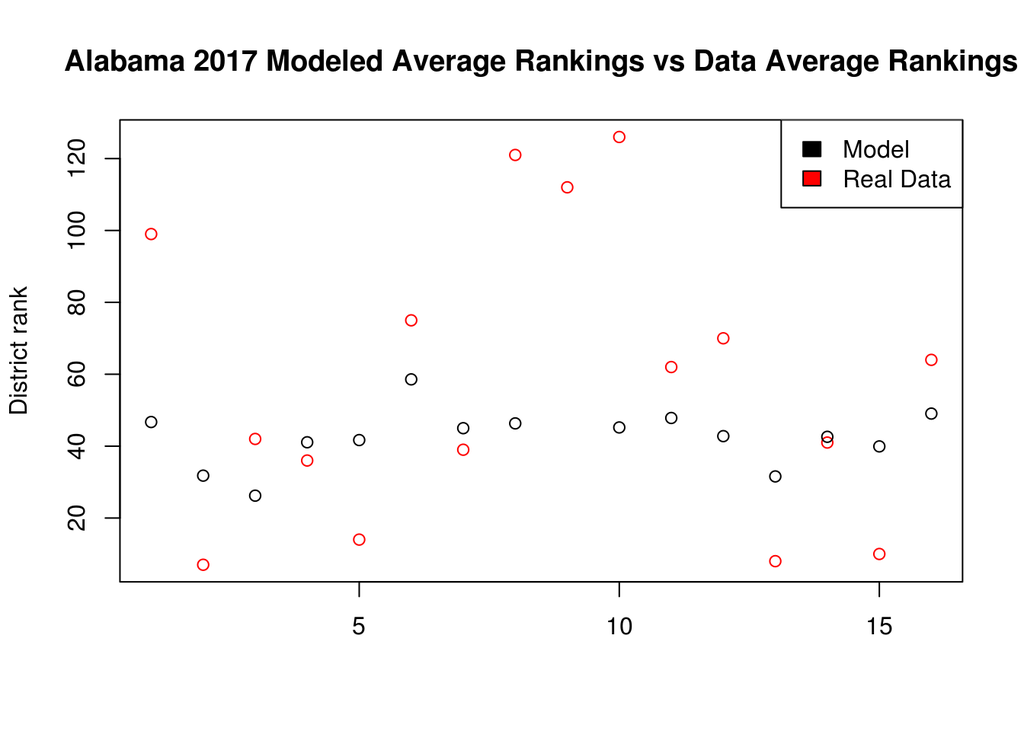

```r
plot(x=1:length(test_avg_rankings),y=test_avg_rankings,type="p",col="red", ylab = "District rank", xlab = "")
  legend("topright",c("Model","Real Data"),fill = c("black","red"))
  points(x=1:length(modeled_avg_rankings),y=modeled_avg_rankings)
  title(main = "Alabama 2017 Modeled Average Rankings vs Data Average Rankings")
```

As you can see the model is not very accurate, especially with lower-ranked schools. The larger the vertical gap there is between each black and red dot on the same x-axis value, the worse the model was at predicting. I already stated the limitation about variation on the model’s results, but there are a few others. One of the other biggest factors about this model is it does not account for size of a district, because generally a larger district would receive more state funding. However since the fall_attendance column was negatively affecting the model, I decided to remove it. Another limitation is that there is no other performance-based data to test against rank, such as average GPA’s or students in advanced classes.